# Part I - (PISA Data)

## Multivariate Exploration

### Question

What is the corromlation between math reading science score and family wealth?

```python
#We create diccionries that group our type to 2 categories numerical and categorical
numeric_vars = ['Math', 'Reading', 'Science', 'Family_wealth']
categoric_vars = ['Gender','Immigration_status', 'computers', 'computer_programming']
family_vars=['Mother_Job','Father_Job','Mother_Schooling', 'Father_Schooling']
```

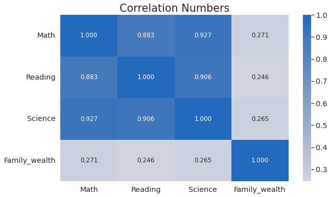

```python
# Correlation plot between numerical variable
sb.heatmap(df_c[numeric_vars].corr(),
           annot=True,
           fmt='.3f',
           cmap='vlag_r',
           center=0)
plt.yticks(rotation=0)
plt.title('Correlation Numbers');
```

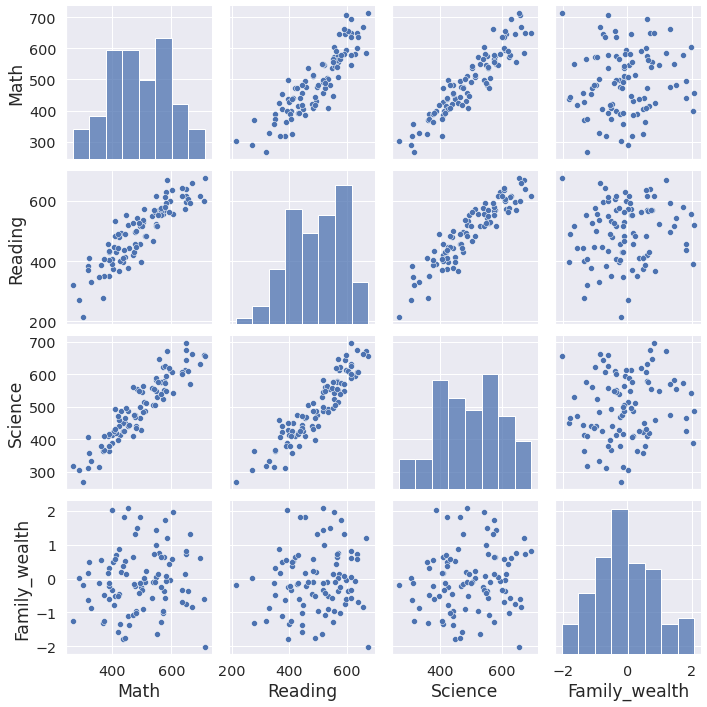

```python
# Plot matrix: sample 500 students so that plots are clearer and
# they render faster
samples = np.random.choice(df_c.shape[0], 500, replace=False)
students_samp = df_c.loc[samples, :].dropna()

sb.pairplot(data=students_samp, vars=numeric_vars)
```

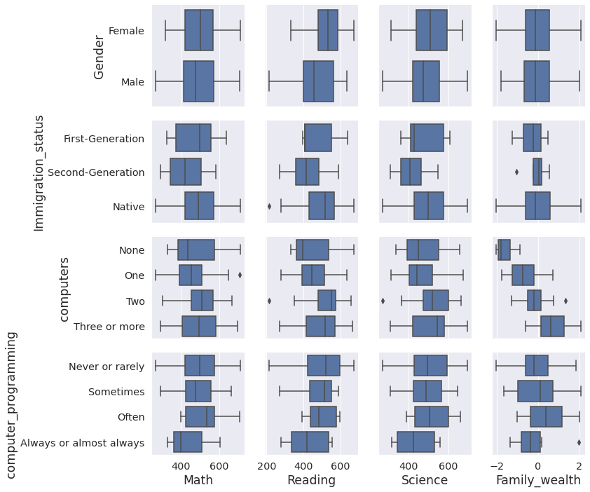

```python
def boxgrid(x, y, **kwargs):
    sb.boxplot(x, y, color=base_color)


g = sb.PairGrid(data=students_samp,
                x_vars=numeric_vars,
                y_vars=categoric_vars)
g.map(boxgrid);
```

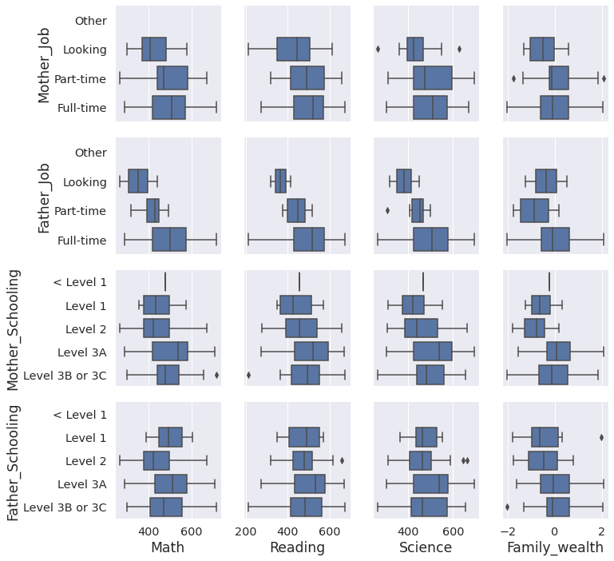

```python
def boxgrid(x, y, **kwargs):
    sb.boxplot(x, y, color=base_color)


h = sb.PairGrid(data=students_samp,
                x_vars=numeric_vars,
                y_vars=family_vars)
h.map(boxgrid);
```

### Observation

Thre is high corrolation between math reading and science score, what is remarkable that computer programming has a negative effect on Math reading and sciecne score

### Question

Is there a relationship between score and gender?

```python
def barplot_scores(data, var, title):
    # Group data by var and calculate mean scores
    data = data.groupby(var)[['Math', 'Reading', 'Science']].mean()

    # Plot barplot
    ax = data.plot.bar(rot=0)
    plt.ylabel('Scores')
    plt.title(title)

    return ax
```

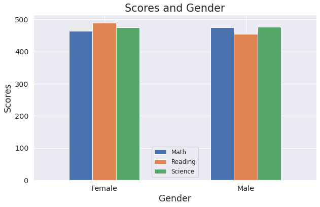

```python
barplot_scores(df_c, 'Gender', 'Scores and Gender');
```

### Observation

Male tend to perform better in Math, Female in reading and they get an equivalent score in Science

### Question

relationship between computer programming and score

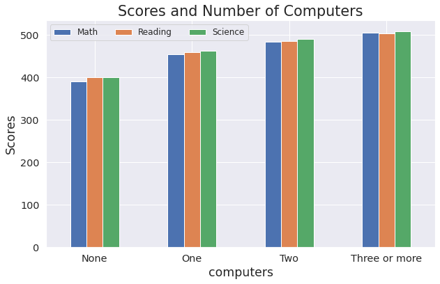

```python
ax = barplot_scores(df_c, 'computers', 'Scores and Number of Computers')
ax.legend(ncol = 3) # re-arrange legend to reduce overlapping
```

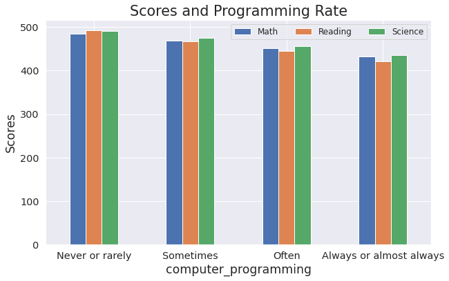

```python
ax = barplot_scores(df_c, 'computer_programming', 'Scores and Programming Rate')
ax.legend(ncol = 3); # re-arrange legend to reduce overlapping
```

### Observation

There is a postive correlatioon between the number of cumputer and scores but curiosliy a negative one between programing and score

### Observation

Relation between gender and score

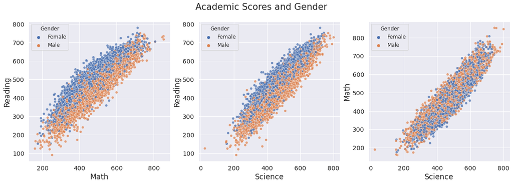

```python
# Plot matrix: sample 10000 students so that plots render faster
samples = np.random.choice(df_c.shape[0], 10000, replace=False)
students_samp = df_c.loc[samples, :]

fig = plt.figure(figsize=[20, 6])
plt.suptitle('Academic Scores and Gender', size='xx-large')

plt.subplot(1, 3, 1)
sb.scatterplot(data=students_samp,
               x='Math',
               y='Reading',
               hue='Gender',
               alpha=0.75)

plt.subplot(1, 3, 2)
sb.scatterplot(data=students_samp,
               x='Science',
               y='Reading',
               hue='Gender',
               alpha=0.75)

plt.subplot(1, 3, 3)
sb.scatterplot(data=students_samp,
               x='Science',
               y='Math',
               hue='Gender',
               alpha=0.75)
```

### Obsevation

As seen before Male tend to have higher score in math girl in reading and similar one in sciecne

### Talk about some of the relationships you observed in this part of the investigation. Were there features that strengthened each other in terms of looking at your feature(s) of interest?

> it can be observed that the math scores for males and females looks very similar - normally distributed, with similar means

## Conclusions

> Student from Mexico and Italy lead in term of number of student with more than 30000, followed by Spain Canda Brazil Australia United Kingdom.

> Shanghai leads the three test foloowed by Asiatic countries. that in Math Reading and science fellowed in second place by Singapore and Hong kong

> 2/3 of student come from OECD, countries with high-income economies with a very high Human Development Index (HDI) and are regarded as developed countries.

> There is clear dominance for OECD countries specially in median score but the gap reduce for outperformer, there is probably due the a better educatif system

> Immigration status does affect Pisa scores as first and second generation performs wors than "native.

> The number of computer clearly have a positive correlation on scores but strangely programming have a negative impact on the three scores.